# Panel Data and Fixed Effects

Our first steps in Panel Data and Fixed Effects with R

### Introduction!

Welcome to our seventh tutorial for the Statistics II: Statistical Modeling & Causal Inference (with R) course.

During this week’s lecture you were introduced to Panel Data and Fixed Effects.

In this lab session we will:

- Create three-way tables with `janitor::tabyl()`
- Visualize trends across time with `ggplot2`
- Learn how to extract our pooled, unit-fixed, and unit- and time-fixed effects estimates with Least Squares Dummy Variables (LSDV) estimation (with `lm()` and the de-meaning approach with `plm()`)

## Measuring the effect of a carbon tax on national carbon dioxide emissions per capita

After all the very valuable output you have generated in the past weeks, you have become a sensation within the policy analysis world. You are hired as an outside consultant by the Organization of Economic Non-Cooperation for Development (OENCD), they are interested in studying the effect of a carbon tax on national carbon dioxide emissions per capita. You are provided with data for the twelve-members of the organization from 2009 to 2019. *The data can be called a balanced panel based on the description given in the lecture (i.e. each panel member is observed every year)*

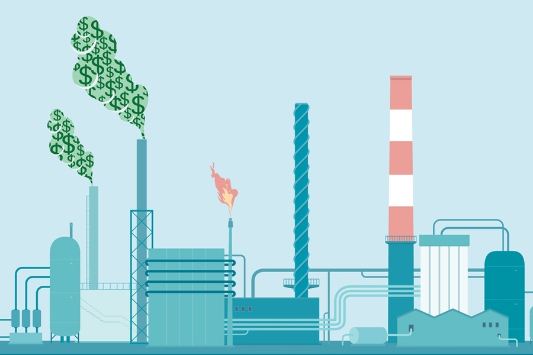

### Packages

```r
# These are the libraries we will use today. Make sure to install them in your console in case you have not done so previously.

set.seed(42) #for consistent results

library(tidyverse)
library(dplyr) # to wrangle our data
library(tidyr) # to wrangle our data - pivot_longer()
library(lubridate) # for working with dates-times in a more intuitive manner
library(ggplot2) # to render our graphs
library(readr) # for loading the .csv data

library(kableExtra) # to render better formatted tables
library(janitor) # for data management and tabyl()
library(modelsummary)  # for formatting your model output

library(lmtest) # to gather our clustered standard errors - coeftest()
library(plm)  # to gather our clustered standard errors - vcovHC() and plm()
library(estimatr) # to run lm_robust() - OLS with robust SE
```

### Our data

```r
carbon_tax_df <- readr::read_csv("https://raw.githubusercontent.com/seramirezruiz/stats-ii-lab/master/Session%207/data/carbon_tax_df.csv") # simulated data
```

Our data set *carbon_tax_df*, contains the following information:

- `country_name`: Name of the country
- `country_code`: Three-letter country code
- `year`: Year
- `tax`: Dummy for whether the carbon tax was in place
- `income_class`: Categorical variable with income label (Low to High)
- `co2_per_capita`: carbon dioxide emissions per capita in metric tons (T)

## Exploratory analysis

#### Let’ explore who had the tax in place at what point

We can use what we have learned about the `janitor::tabyl()` function to check how many observations we have for each of the countries:

- One-way table:

```r
carbon_tax_df %>%
  janitor::tabyl(country_name) %>%
  janitor::adorn_pct_formatting(digits = 1) %>%
  knitr::kable(col.names = c("Country", "N", "Percent, %")) %>%
  kableExtra::kable_styling()
```

| Country | N | Percent, % |
| --- | --- | --- |
| Adjikistan | 11 | 8.3% |
| Borovia | 11 | 8.3% |
| Carpania | 11 | 8.3% |
| Corinthia | 11 | 8.3% |
| Freedonia | 11 | 8.3% |
| Glenraven | 11 | 8.3% |
| Khemed | 11 | 8.3% |
| Laurania | 11 | 8.3% |
| Parano | 11 | 8.3% |
| Ron | 11 | 8.3% |
| Rumekistan | 11 | 8.3% |
| Transia | 11 | 8.3% |

We can also explore how many countries had a `tax` in place every year.

- Two-way table:

```r
carbon_tax_df %>%
  janitor::tabyl(tax, year) %>%
  janitor::adorn_percentages("col") %>%
  janitor::adorn_pct_formatting(digits = 1) %>%
  janitor::adorn_ns() %>%
  knitr::kable() %>%
  kableExtra::kable_styling() %>%
  kableExtra::add_header_above(c("", "Year" = 11))
```

| tax | Year 2009 | Year 2010 | Year 2011 | Year 2012 | Year 2013 | Year 2014 | Year 2015 | Year 2016 | Year 2017 | Year 2018 | Year 2019 |
| --- | --- | --- | --- | --- | --- | --- | --- | --- | --- | --- | --- |
| 0 | 100.0% (12) | 100.0% (12) | 83.3% (10) | 75.0% (9) | 66.7% (8) | 66.7% (8) | 41.7% (5) | 33.3% (4) | 33.3% (4) | 33.3% (4) | 41.7% (5) |
| 1 | 0.0% (0) | 0.0% (0) | 16.7% (2) | 25.0% (3) | 33.3% (4) | 33.3% (4) | 58.3% (7) | 66.7% (8) | 66.7% (8) | 66.7% (8) | 58.3% (7) |

We can further explore how many countries had a `tax` in place every year at the `income_class` cluster:

- Three-way table:

```r
carbon_tax_df %>%
  janitor::tabyl(tax, year, income_class) %>%
  janitor::adorn_percentages("col") %>%
  janitor::adorn_pct_formatting(digits = 1) %>%
  janitor::adorn_ns()
```

```
## $High
##  tax       2009       2010      2011      2012      2013      2014      2015
##    0 100.0% (3) 100.0% (3) 66.7% (2) 66.7% (2) 33.3% (1) 33.3% (1) 33.3% (1)
##    1   0.0% (0)   0.0% (0) 33.3% (1) 33.3% (1) 66.7% (2) 66.7% (2) 66.7% (2)
##       2016      2017      2018      2019
##  33.3% (1) 33.3% (1) 33.3% (1) 33.3% (1)
##  66.7% (2) 66.7% (2) 66.7% (2) 66.7% (2)
##
## $`High-Middle`
##  tax       2009       2010      2011      2012      2013      2014       2015
##    0 100.0% (3) 100.0% (3) 66.7% (2) 66.7% (2) 66.7% (2) 66.7% (2)   0.0% (0)
##    1   0.0% (0)   0.0% (0) 33.3% (1) 33.3% (1) 33.3% (1) 33.3% (1) 100.0% (3)
##        2016       2017       2018      2019
##    0.0% (0)   0.0% (0)   0.0% (0) 33.3% (1)
##  100.0% (3) 100.0% (3) 100.0% (3) 66.7% (2)
##
## $Low
##  tax       2009       2010       2011       2012       2013       2014
##    0 100.0% (3) 100.0% (3) 100.0% (3) 100.0% (3) 100.0% (3) 100.0% (3)
##    1   0.0% (0)   0.0% (0)   0.0% (0)   0.0% (0)   0.0% (0)   0.0% (0)
##        2015      2016      2017      2018      2019
##  100.0% (3) 66.7% (2) 66.7% (2) 66.7% (2) 66.7% (2)
##    0.0% (0) 33.3% (1) 33.3% (1) 33.3% (1) 33.3% (1)
##
## $`Low-Middle`
##  tax       2009       2010       2011      2012      2013      2014      2015
##    0 100.0% (3) 100.0% (3) 100.0% (3) 66.7% (2) 66.7% (2) 66.7% (2) 33.3% (1)
##    1   0.0% (0)   0.0% (0)   0.0% (0) 33.3% (1) 33.3% (1) 33.3% (1) 66.7% (2)
##       2016      2017      2018      2019
##  33.3% (1) 33.3% (1) 33.3% (1) 33.3% (1)
##  66.7% (2) 66.7% (2) 66.7% (2) 66.7% (2)
```

As we can see, the three-way table creates a list containing the different combinations which are accessible with the `$` operator. We can do a little bit of code gymnastics to generate our nicely formatted output by saving the `janitor::tabyl()` output into an object and printing each of the tables individually.

```r
three_way_tab <- carbon_tax_df %>%
  janitor::tabyl(tax, year, income_class) %>%
  janitor::adorn_percentages("col") %>%
  janitor::adorn_pct_formatting(digits = 1) %>%
  janitor::adorn_ns()
```

| High tax | High Year 2009 | High Year 2010 | High Year 2011 | High Year 2012 | High Year 2013 | High Year 2014 | High Year 2015 | High Year 2016 | High Year 2017 | High Year 2018 | High Year 2019 |
| --- | --- | --- | --- | --- | --- | --- | --- | --- | --- | --- | --- |
| 0 | 100.0% (3) | 100.0% (3) | 66.7% (2) | 66.7% (2) | 33.3% (1) | 33.3% (1) | 33.3% (1) | 33.3% (1) | 33.3% (1) | 33.3% (1) | 33.3% (1) |
| 1 | 0.0% (0) | 0.0% (0) | 33.3% (1) | 33.3% (1) | 66.7% (2) | 66.7% (2) | 66.7% (2) | 66.7% (2) | 66.7% (2) | 66.7% (2) | 66.7% (2) |

| High-Middle tax | High-Middle Year 2009 | High-Middle Year 2010 | High-Middle Year 2011 | High-Middle Year 2012 | High-Middle Year 2013 | High-Middle Year 2014 | High-Middle Year 2015 | High-Middle Year 2016 | High-Middle Year 2017 | High-Middle Year 2018 | High-Middle Year 2019 |
| --- | --- | --- | --- | --- | --- | --- | --- | --- | --- | --- | --- |
| 0 | 100.0% (3) | 100.0% (3) | 66.7% (2) | 66.7% (2) | 66.7% (2) | 66.7% (2) | 0.0% (0) | 0.0% (0) | 0.0% (0) | 0.0% (0) | 33.3% (1) |
| 1 | 0.0% (0) | 0.0% (0) | 33.3% (1) | 33.3% (1) | 33.3% (1) | 33.3% (1) | 100.0% (3) | 100.0% (3) | 100.0% (3) | 100.0% (3) | 66.7% (2) |

| Low-Middle tax | Low-Middle Year 2009 | Low-Middle Year 2010 | Low-Middle Year 2011 | Low-Middle Year 2012 | Low-Middle Year 2013 | Low-Middle Year 2014 | Low-Middle Year 2015 | Low-Middle Year 2016 | Low-Middle Year 2017 | Low-Middle Year 2018 | Low-Middle Year 2019 |
| --- | --- | --- | --- | --- | --- | --- | --- | --- | --- | --- | --- |
| 0 | 100.0% (3) | 100.0% (3) | 100.0% (3) | 66.7% (2) | 66.7% (2) | 66.7% (2) | 33.3% (1) | 33.3% (1) | 33.3% (1) | 33.3% (1) | 33.3% (1) |
| 1 | 0.0% (0) | 0.0% (0) | 0.0% (0) | 33.3% (1) | 33.3% (1) | 33.3% (1) | 66.7% (2) | 66.7% (2) | 66.7% (2) | 66.7% (2) | 66.7% (2) |

| Low tax | Low Year 2009 | Low Year 2010 | Low Year 2011 | Low Year 2012 | Low Year 2013 | Low Year 2014 | Low Year 2015 | Low Year 2016 | Low Year 2017 | Low Year 2018 | Low Year 2019 |
| --- | --- | --- | --- | --- | --- | --- | --- | --- | --- | --- | --- |
| 0 | 100.0% (3) | 100.0% (3) | 100.0% (3) | 100.0% (3) | 100.0% (3) | 100.0% (3) | 100.0% (3) | 66.7% (2) | 66.7% (2) | 66.7% (2) | 66.7% (2) |
| 1 | 0.0% (0) | 0.0% (0) | 0.0% (0) | 0.0% (0) | 0.0% (0) | 0.0% (0) | 0.0% (0) | 33.3% (1) | 33.3% (1) | 33.3% (1) | 33.3% (1) |

#### Let’s explore visually the levels of carbon dioxide emmissions

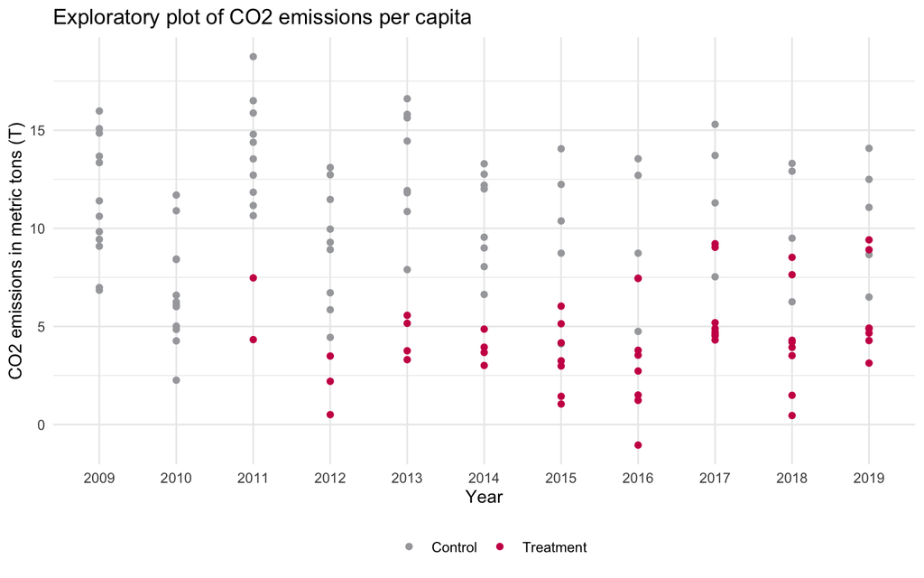

```r
ggplot(carbon_tax_df, aes(x = factor(year),
                          y= co2_per_capita,
                          color = factor(tax))) +
  geom_point() + #create scatterplot
  labs(title = "Exploratory plot of CO2 emissions per capita",
       x = "Year",
       y = "CO2 emissions in metric tons (T)",
       color = "Carbon tax")  +
  theme_minimal() +
  theme(legend.position="bottom") + #move legend to the bottom
  scale_color_manual(name = " ", # changes to fill dimension
                     values = c("#a7a8aa", "#cc0055"),
                     labels = c("Control", "Treatment"))
```

- **What do we see here?**

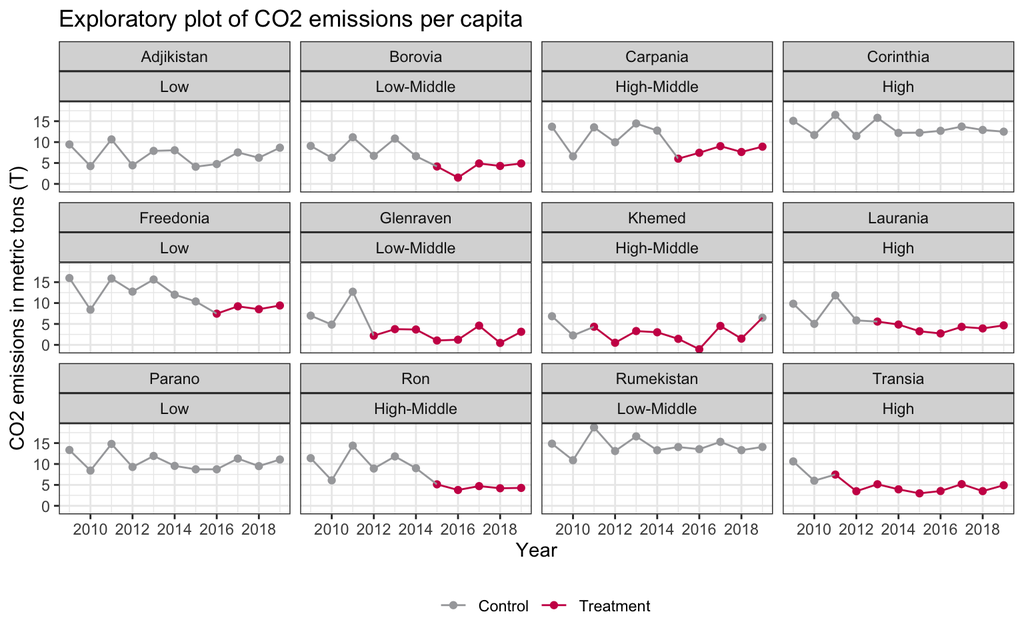

```r
carbon_tax_df %>%
  dplyr::mutate(year_as_date = lubridate::ymd(year, truncated = 2L), #turning numeric to date format
                income_class = factor(carbon_tax_df$income_class,
                                      levels = c("High", "High-Middle",
                                                 "Low-Middle", "Low"))) %>% #reordering the factors
  ggplot(., aes(x = year_as_date,
                y= co2_per_capita,
                color = factor(tax))) +
  geom_point() + #create scatterplot
    #to render consecutive lines disregarding the tax
  facet_wrap(country_name~income_class) + #to split plot into panels based on this dimension
  geom_line(aes(group = 1)) +
  scale_x_date(date_labels = "%Y") + #telling ggplot that we want the ticks to be the years in the dates
  labs(title = "Exploratory plot of CO2 emissions per capita",
       x = "Year",
       y = "CO2 emissions in metric tons (T)",
       color = "Carbon tax") +
  theme_bw() +
  scale_color_manual(name = " ", # changes to fill dimension
                     values = c("#a7a8aa", "#cc0055"),
                     labels = c("Control", "Treatment")) +
  theme(legend.position = "bottom")
```

- **What do we see here?**

*Note: The exploratory data analysis portions of our scripts might not transfer directly to this week’s assignment; however, they will be very useful for your future endeavors. Summarizing, graphing, and exploring your data will be critical to discover patterns, to spot anomalies, and to check assumptions*

## Modeling and estimating

We have seen during the lecture that balanced panel data can help us decompose the error term. With a balanced panel we can capture all unobserved, unit- and time-specific factors.

In the example at hand, we can think of unit-specific factors as characteristics of individual countries that are constant over time (e.g. a country that just loves big pick-up trucks). We can also think about time-specific factors that affect all countries (e.g. global economic shocks).

We can formulate this as:

$$Y_{it} = β_0 + β_1D_{it} + \theta_{i} +
\delta_t + \upsilon_{it}$$

where $\theta_i$ reflects the time-invariant traits of the units, $\delta_t$ reflects the time-specific factors that affect everyone and $\upsilon_{it}$ is the **idiosyncratic error**

We will move forward by creating three models:

- A **naive model** (also known as a *pooled model*), where we will regress `co2_per_capita` on `tax`.
- A **model with unit-fixed effects**, where we will capture the $\theta$ portion of our error
- A **model with time- and unit-fixed effects**, where we will capture our $\delta$ and $\theta$ portions of our error term

### Naive modeling

```r
naive_carbon <- lm(co2_per_capita ~ tax, data = carbon_tax_df)
pooled_naive_carbon <- plm::plm(co2_per_capita ~ tax,
                           data = carbon_tax_df,
                           model = "pooling") # performs regular OLS
```

#### Naive model with lm()

```r
modelsummary::modelsummary(naive_carbon,
                           stars = c('*' = .1, '**' = .05, '***' = .01),
                           statistic = 'conf.int',
                           gof_omit = "AIC|BIC|Log.Lik.",
                           fmt = 2)
```

|  | Model 1 |
| --- | --- |
| (Intercept) | 10.63*** |
|  | [9.93, 11.32] |
| tax | −6.26*** |
|  | [−7.38, −5.14] |
| Num.Obs. | 132 |
| R2 | 0.485 |
| R2 Adj. | 0.481 |
| F | 122.394 |
| RMSE | 3.14 |

#### Naive model with plm()

```r
modelsummary::modelsummary(pooled_naive_carbon,
                           stars = c('*' = .1, '**' = .05, '***' = .01),
                           statistic = 'conf.int',
                           gof_omit = "AIC|BIC|Log.Lik.",
                           fmt = 2)
```

|  | Model 1 |
| --- | --- |
| (Intercept) | 10.63*** |
|  | [9.93, 11.32] |
| tax | −6.26*** |
|  | [−7.38, −5.14] |
| Num.Obs. | 132 |
| R2 | 0.485 |
| R2 Adj. | 0.481 |
| RMSE | 3.14 |

**What do we see here?**

This model is telling us that on average, the $CO_2$ emissions per capita are associated with a reduction of 6.2 metric tons when a carbon tax is put in place. Still, after all the work we have done throughout the semester, we understand that there may be a plethora of factors that could be skewing the results of this bivariate regression.

### Unit-fixed effects

We will learn two ways of gathering unit- and time-fixed effects in R:

First, we will perform **Least Squares Dummy Variables (LSDV) estimation** with *lm()*, where we essentially get an individual estimate for each unit.

Second, we will run our model with *plm()*, which will do the same mechanics, yet it will not estimate each of the units intercepts (because it relies on the “de-meaning” approach).

```r
lsdv_unit_fe <- lm(co2_per_capita ~ tax + country_name, data = carbon_tax_df)

unit_fe <- plm::plm(co2_per_capita ~ tax,
               data = carbon_tax_df,
               index = c("country_name"), # unit
               effect = "individual",
               model = "within")
```

#### Unit-fixed effects with lm() — Least Squares Dummy Variables (LSDV) estimation

```r
modelsummary::modelsummary(lsdv_unit_fe,
                           stars = c('*' = .1, '**' = .05, '***' = .01),
                           statistic = 'conf.int',
                           gof_omit = "AIC|BIC|Log.Lik.",
                           fmt = 2)
```

|  | Model 1 |
| --- | --- |
| (Intercept) | 6.91*** |
|  | [5.67, 8.15] |
| tax | −4.44*** |
|  | [−5.37, −3.50] |
| country_nameBorovia | 1.51 |
|  | [−0.30, 3.31] |
| country_nameCarpania | 5.11*** |
|  | [3.30, 6.91] |
| country_nameCorinthia | 6.43*** |
|  | [4.68, 8.19] |
| country_nameFreedonia | 6.12*** |
|  | [4.33, 7.91] |
| country_nameGlenraven | 0.37 |
|  | [−1.51, 2.26] |
| country_nameKhemed | −0.67 |
|  | [−2.56, 1.21] |
| country_nameLaurania | 1.53 |
|  | [−0.32, 3.39] |
| country_nameParano | 3.69*** |
|  | [1.94, 5.45] |
| country_nameRon | 2.71*** |
|  | [0.91, 4.52] |
| country_nameRumekistan | 7.43*** |
|  | [5.68, 9.19] |
| country_nameTransia | 1.88* |
|  | [−0.03, 3.80] |
| Num.Obs. | 132 |
| R2 | 0.797 |
| R2 Adj. | 0.776 |
| F | 38.844 |
| RMSE | 1.97 |

#### Unit-fixed effects with plm()

```r
modelsummary::modelsummary(unit_fe,
                           stars = c('*' = .1, '**' = .05, '***' = .01),
                           statistic = 'conf.int',
                           gof_omit = "AIC|BIC|Log.Lik.",
                           fmt = 2)
```

|  | Model 1 |
| --- | --- |
| tax | −4.44*** |
|  | [−5.37, −3.50] |
| Num.Obs. | 132 |
| R2 | 0.424 |
| R2 Adj. | 0.366 |
| RMSE | 1.97 |

**What do we see here?**

Adding unit-level fixed effects to the model, i.e. accounting for unobserved, time-invariant characteristics of countries and only focusing on within-state variation, the imposition of a carbon tax reduces $CO_2$ per capita emissions by **4.44 metric tons**. Once we have captured the variation between countries, we can see that our results from the naive model were substantially biased. We can still try to capture the time-specific portion of the error.

*The results from the Least Squares Dummy Variables (LSDV) estimation are read in reference to a baseline. In this case, the constant is representing the intercept for Adjikistan. We can utilize the individual slopes for each country to say that Freedonians emit on average 6.12 more metric tons of $CO_2$ per capita than Adjikistanians.*

### Unit- and time-fixed effects

We will perform our regressions with **Least Squares Dummy Variables (LSDV) estimation** with *lm()* and our simplified way with *plm()*.

```r
lsdv_unit_time_fe <- lm(co2_per_capita ~ tax + country_name + factor(year),
                        data = carbon_tax_df)

unit_time_fe <- plm::plm(co2_per_capita ~ tax,
                    data = carbon_tax_df,
                    index = c("country_name", "year"), # unit and time
                    model = "within",
                    effect = "twoways")
```

#### Unit- and time-fixed effects with lm() — Least Squares Dummy Variables (LSDV) estimation

```r
modelsummary::modelsummary(lsdv_unit_time_fe,
                           stars = c('*' = .1, '**' = .05, '***' = .01),
                           statistic = 'conf.int',
                           gof_omit = "AIC|BIC|Log.Lik.",
                           fmt = 2)
```

|  | Model 1 |
| --- | --- |
| (Intercept) | 8.62*** |
|  | [7.84, 9.41] |
| tax | −3.91*** |
|  | [−4.46, −3.35] |
| country_nameBorovia | 1.27*** |
|  | [0.44, 2.09] |
| country_nameCarpania | 4.87*** |
|  | [4.04, 5.69] |
| country_nameCorinthia | 6.43*** |
|  | [5.65, 7.22] |
| country_nameFreedonia | 5.93*** |
|  | [5.11, 6.74] |
| country_nameGlenraven | −0.01 |
|  | [−0.90, 0.87] |
| country_nameKhemed | −1.06** |
|  | [−1.94, −0.17] |
| country_nameLaurania | 1.20*** |
|  | [0.33, 2.06] |
| country_nameParano | 3.69*** |
|  | [2.90, 4.48] |
| country_nameRon | 2.47*** |
|  | [1.65, 3.30] |
| country_nameRumekistan | 7.43*** |
|  | [6.64, 8.22] |
| country_nameTransia | 1.45*** |
|  | [0.54, 2.36] |
| factor(year)2010 | −4.70*** |
|  | [−5.45, −3.94] |
| factor(year)2011 | 1.89*** |
|  | [1.13, 2.65] |
| factor(year)2012 | −3.06*** |
|  | [−3.83, −2.29] |
| factor(year)2013 | 0.11 |
|  | [−0.67, 0.88] |
| factor(year)2014 | −1.88*** |
|  | [−2.65, −1.10] |
| factor(year)2015 | −3.02*** |
|  | [−3.84, −2.20] |
| factor(year)2016 | −3.29*** |
|  | [−4.13, −2.45] |
| factor(year)2017 | −0.96** |
|  | [−1.80, −0.12] |
| factor(year)2018 | −2.49*** |
|  | [−3.33, −1.65] |
| factor(year)2019 | −1.40*** |
|  | [−2.22, −0.58] |
| Num.Obs. | 132 |
| R2 | 0.963 |
| R2 Adj. | 0.955 |
| F | 127.305 |
| RMSE | 0.85 |

```r
modelsummary::modelsummary(unit_time_fe,
                           stars = c('*' = .1, '**' = .05, '***' = .01),
                           statistic = 'conf.int',
                           gof_omit = "AIC|BIC|Log.Lik.",
                           fmt = 2)
```

|  | Model 1 |
| --- | --- |
| tax | −3.91*** |
|  | [−4.46, −3.35] |
| Num.Obs. | 132 |
| R2 | 0.641 |
| R2 Adj. | 0.568 |
| RMSE | 0.85 |

**What do we see here?**

Now in addition to adding unit-level fixed effects to the model, we control for time-specific factors that affect the global per capita $CO_2$ emissions. The results suggest that the effect of a carbon-tax leads to a decrease $CO_2$ emissions of 3.91 metric tons per capita.

#### Test of serial correlation for the idiosyncratic component of the errors in panel models

> The model assumes that the errors in the dependent variable (i.e., the difference between the actual values and the predicted values) are independently and identically distributed (iid) with a mean of zero and a constant variance. However, when the panel data has a large number of time periods, it’s common for the errors to be correlated over time. In other words, the error term in one period is related to the error term in the previous period. This is known as serial correlation and it violates the independence assumption of the model.

In our models our assumption for the errors is $υ_{it} ∼ iid(0, σ_υ^{2})$.

With longer panels, serial correlation between errors is a problem:

$Cor(υ_{it}, υ_i(t−1))≠0$.

We can test for serial correlation in our time and unit FE specification model, as such:

```r
plm::pbgtest(unit_time_fe, order = 2)
```

```
##
##  Breusch-Godfrey/Wooldridge test for serial correlation in panel models
##
## data:  co2_per_capita ~ tax
## chisq = 0.25101, df = 2, p-value = 0.8821
## alternative hypothesis: serial correlation in idiosyncratic errors
```

```r
model_with_robust_se <- estimatr::lm_robust(co2_per_capita ~ tax + country_name + factor(year),
                        data = carbon_tax_df)
```

## Drafting some brief recommedations

You report back to the Organization of Economic Non-Cooperation for Development (OENCD). Based on your analysis of the data at hand, you suggest that the implementation of a carbon tax does have an effect on national carbon dioxide emissions per capita. Your results show that a carbon tax reduces $CO_2$ emissions by 3.91 metric tons per capita.

Your results are welcomed internationally and all states move forward with the measure.

# **Acknowledgements**

This script was drafted by [Lisa Oswald](https://lfoswald.github.io/) and [Sebastian Ramirez-Ruiz](https://seramirezruiz.github.io/), with contributions by [Adelaida Barrera Daza](https://www.linkedin.com/in/adelaidabarrera/), [Carolina Díaz Suárez](https://www.linkedin.com/in/carolinadiazsuarez/), [Sofía García-Durrer](https://www.linkedin.com/in/sofia-garcia-durrer/), and [William Fernandez](https://www.hertie-school.org/en/who-we-are/profile/person/tinoco).